# Workshop1_2018_APS273

APB

15/02/2018

## Getting Started with Matrix Models

This is a workbook to learn how to do some conservation *biology* **modelling**. It is an RMarkdown document.

The first thing we need to do is get some libraries working for us. Remember, if you have not already installed these, you must do that FIRST (but only ONCE).

```r
library(dplyr)
```

```r
library(ggplot2)
library(popbio)
```

## Matrix multiplication basics in R

This section helps you learn how matrix multiplication works.

First, lets make a matrix that is 2 x 2. This is a matrix that defines the fertilities and surivals for a simple 2-stage (Juvenile and Adult) life cycle.

```r
myMat <- matrix(c(0,2,0.5,0.1), nrow = 2, byrow = TRUE)
myMat
```

```
##      [,1] [,2]
## [1,]  0.0  2.0
## [2,]  0.5  0.1
```

In order to do matrix multiplication, we need a vector of starting numbers in each age class. Because the matrix is 2 x 2, there are 2 age classes…. I’ll start with 10 and 10.

```r
n0 <- c(10,10)
```

Matrix multiplication uses the `%*%` function in R. The following multiplication is like projecting the population (n0 now) into the future by 1 year.

```r
myMat %*% n0
```

```
##      [,1]
## [1,]   20
## [2,]    6
```

Now we are going to make a *LOOP* that does the iteration of the matrix through several time steps… we will get back a time series of population size in each age class.

This is the setup

```r
# First define the number of years
# how many years into the future
times <- 50

# Second, make a collection box into which we put the projections
# the box is a matrix with two columns, one for each age class.
pops <-matrix(data = NA, nrow = times, ncol = 2)

# Third, make the first row of pops = c(10,10)
# the pops[1,] is a way to specify the first (1) row (,) of the pops vector
# we've assigned n0 from above to the first row.
pops[1,] <- n0

# let's look at it
pops
```

```
##       [,1] [,2]
##  [1,]   10   10
##  [2,]   NA   NA
##  [3,]   NA   NA
##  [4,]   NA   NA
##  [5,]   NA   NA
##  [6,]   NA   NA
##  [7,]   NA   NA
##  [8,]   NA   NA
##  [9,]   NA   NA
## [10,]   NA   NA
## [11,]   NA   NA
## [12,]   NA   NA
## [13,]   NA   NA
## [14,]   NA   NA
```

[output cut: 36 more lines]

NEXT -> the looping code. For each time step, we project forward. It fills in rows in the SUBSENQUENT row of the pops collection matrix. Row 2 gets filled in by using row 1 numbers. Row 3 gets filled in using row 2 numbers, after they got calculated… and so on. Thats pops[(i),] gets filled in using pops[(i-1),].

```r
# we start counting from 2 because we specify time 1 (n0).
for (i in 2:times){
  # The current row i is created by multiplying the previous row (i-1)
  # by the projection matrix.
  pops[i,] <- myMat %*% pops[(i-1),]
}

# Now look again!
pops
```

```
##            [,1]      [,2]
##  [1,]  10.00000 10.000000
##  [2,]  20.00000  6.000000
##  [3,]  12.00000 10.600000
##  [4,]  21.20000  7.060000
##  [5,]  14.12000 11.306000
##  [6,]  22.61200  8.190600
##  [7,]  16.38120 12.125060
##  [8,]  24.25012  9.403106
##  [9,]  18.80621 13.065371
## [10,]  26.13074 10.709643
## [11,]  21.41929 14.136335
## [12,]  28.27267 12.123277
## [13,]  24.24655 15.348663
## [14,]  30.69733 13.658143
```

[output cut: 36 more lines]

CHALLENGE: Repeat the above exercise with the i counter starting at 1.

```r
# First define the number of years
# how many years into the future
times <- 10

# Second, make a collection box into which we put the projections
# the box is a matrix with two columns, one for each age class.
pops_2 <-matrix(data = NA, nrow = times, ncol = 2)

# Third, make the first row of pops = c(10,10)
# the pops[1,] is a way to specify the first (1) row (,) of the pops vector
# we've assigned n0 from above to the first row.
pops_2[1,] <- n0


for (i in 1:49){
  pops_2[(i+1)] <-
}
```

### Lets learn a quick way to visualise this.

Lets see how to use ggplot and dplyr to turn this into a graph

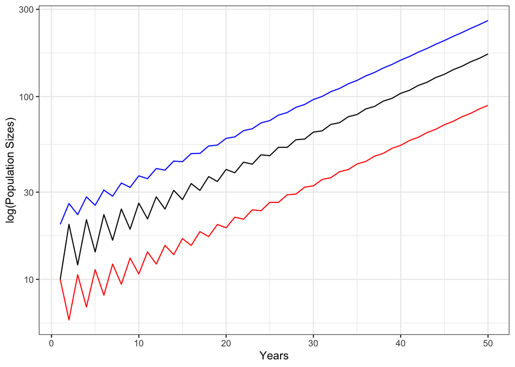

```r
# first make the output a data frame
plotPops <- as.data.frame(pops)

# second add informative names to the columns
names(plotPops) <- c("J", "A")

# Third, add a total population size column
# and a time column
plotPops <- plotPops %>%
  mutate(TotalN = J+A,
         time = 1:times)

# Fourth use ggplot2 to make the picture
ggplot(plotPops, aes(x = time, y = J))+
  geom_line()+
  geom_line(aes(x = time, y = A), col = 'red')+
  geom_line(aes(x = time, y = TotalN), col = 'blue')+
  scale_y_log10()+
  ylab("log(Population Sizes)")+ xlab("Years")+
  theme_bw()
```

The black line is J, the red is A and the blue is Total. What we can see here is that the population is increasing.

### CHALLENGE: Change the time value to 50 now, and see if the *cycles* dampen? When the lines are parallel… what has happened?

## dplyr ggplot Complex Learning

The above dataframe is not set up like a tidy data frame. It is too wide - the three columns that represent population sizes should all be one column of numbers and one column specifying the stage. We can do this with a function in the tidyr package called pivot_longer. Anyone who has made a pivot table in excel might understand this process a bit.

You will need to install *tidyr* to do this.

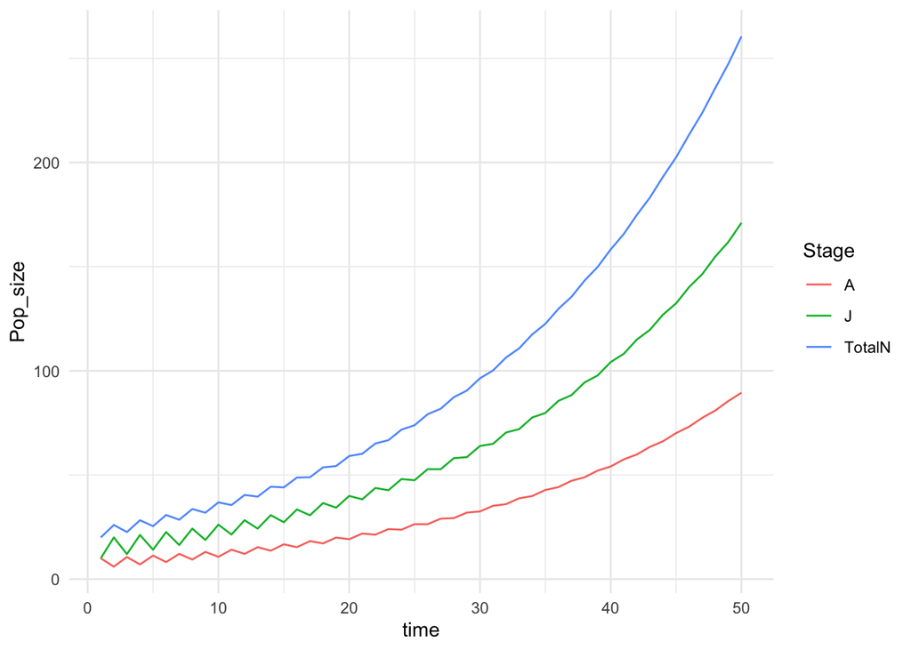

```r
# longify
long_pop <- plotPops %>%
  tidyr::pivot_longer(-time, names_to = "Stage", values_to = "Pop_size")

ggplot(long_pop, aes(x = time, y = Pop_size, colour = Stage, group = Stage))+
  geom_line()+
  theme_minimal()
```

## Lambda, stage distribution and sensitivity/elasticity

In this section, we will learn how to calculate lambda - the population growth rate - the stable stage distribution and sensitivities/elasticities. We will use the functions in the *popbio* package to do this. This is a lovely package to play with, and has an associated two books: the package consists of the R translation of Matlab code found in Caswell (2001) or Morris and Doak (2002).

You can check out the help file of popbio using `??popbio` and clicking through the link for **popbio::01.Introduction**

the *popbio* package has some helper functions that make this stuff easy.

#### Population growth rate

Remember that lambda is an indication of whether the population is growing, steady or declining. We know from the simulations above that the population is growing. This means the lambda should be >1.

```r
# lambda - the asymptotic population growth rate
lambda(myMat)
```

```
## [1] 1.051249
```

#### Stage/Age Structure

The challenge question above about parallel lines was specifically about the ‘stable stage/age distribution’. In these models, the population eventially settles on a CONSTANT ratio among all stages. The proportion of the total population in each age/stage is constant.

We can get that from this code.

```r
# stable stage distribution
stable.stage(myMat)
```

```
## [1] 0.6554692 0.3445308
```

#### *popbio* also has some clever simulation and plotting tools

Let’s recreate our plots with less code and the *popbio* functions.

```r
# first run the simulations.  This is doing the looping you coded above
out <- pop.projection(myMat, n0, times)

# what does this produce?  Familiar?
names(out)
```

```
## [1] "lambda"        "stable.stage"  "stage.vectors" "pop.sizes"
## [5] "pop.changes"
```

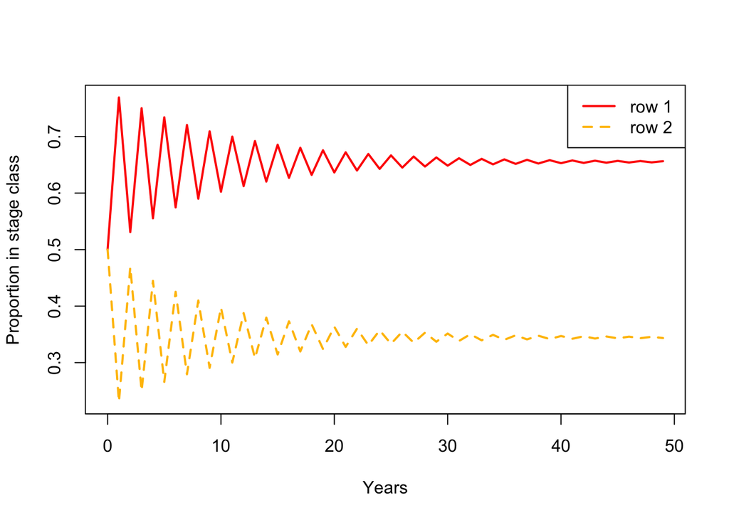

```r
# stage vector plot - this is a plot of the proportion in each stage
# cool!
stage.vector.plot(out$stage.vectors)
```

#### Last steps: sensitivity and elasticity.

We are using functions `sensitivity` and `elasticity` from *popbio*. Remember that the goal in conservation planning is often to identify whether an absolute or percentage increase in the size of a particular age/stage class could reverse a declining population trend.

To do this, we ask, for a change in the fertility or surivival (absolute = sensitivity, percentage = elasticity), what is the change in lambda. If it’s big, the stage/age is ‘important’. If it’s small, it’s not.

Remember too - one of the reasons elasticities are important is because survival is always a fraction between 0 and 1, but fertilities are bounded only by 0 at the bottom. They can be big and whole numbers. We say that they are on different scales.

Another way to think about this is that you can not ask about the effect of a change of 2 for a survial, but you can for fertility - survival can’t be above 1. However, you can ask about a 10% change…. this makes the analysis standardised.

```r
# Sensitivity Analysis
sensMat <- sensitivity(myMat)

# Elasticity Analysis
elasMat <- elasticity(myMat)

# look at them
sensMat
```

```
##           [,1]      [,2]
## [1,] 0.4750312 0.2496881
## [2,] 0.9987523 0.5249688
```

```r
elasMat
```

```
##           [,1]       [,2]
## [1,] 0.0000000 0.47503119
## [2,] 0.4750312 0.04993762
```

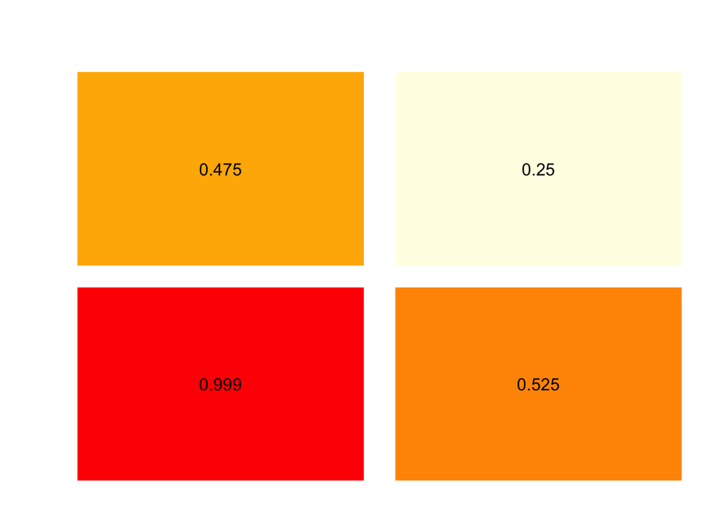

```r
# plot them!
image2(sensMat)
```

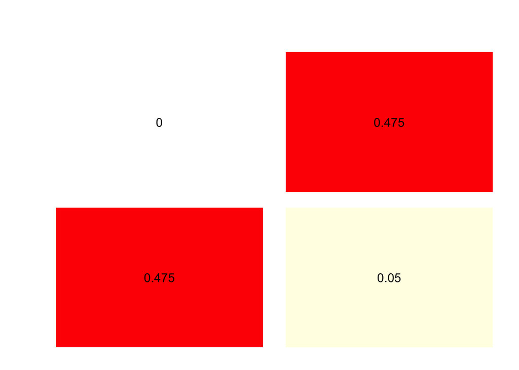

```r
image2(elasMat)
```

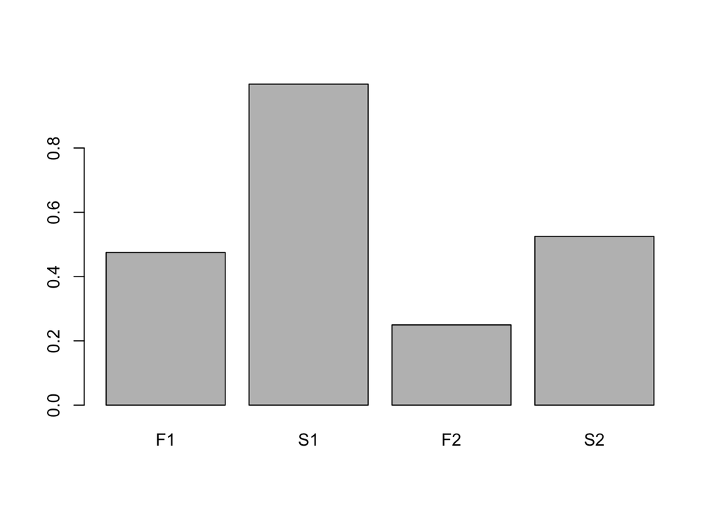

```r
# OR - like the barplots in the Doak Reading
barplot(as.vector(sensMat), names.arg = c("F1","S1", "F2", "S2"))
```